# Visit Scotland Notebook

## Load Libraries

```r
library(tidyverse)
library(here)
library(sf)
library(infer)
library(ggridges)
library(modelr)
library(skimr)
```

## Run Cleaning Script

```r
source(here("scripts/cleaning_script.R"))
```

## Read In Clean Data

```r
regional_domestic_tourism_all <- read_csv(here("data/clean_data/regional_domestic_tourism_all_clean.csv"))
regional_domestic_tourism_individual <- read_csv(here("data/clean_data/regional_domestic_tourism_individual_clean.csv"))
regional_domestic_tourism_non_gb_clean <- read_csv(here("data/clean_data/regional_domestic_tourism_non_gb_clean.csv"))
international_visits <- read_csv(here("data/clean_data/international_visits_clean.csv"))
tourism_businesses <- read_csv(here("data/clean_data/tourism_businesses_clean.csv"))
local_authority_geo <- st_read(dsn = "data/geo_data/", layer = "pub_las")
```

## Annual Average Stats

#### 5 Figure Summary

```r
regional_domestic_tourism_all %>%
  skim()
```

```
── Data Summary ────────────────────────
                           Values
Name                       Piped data
Number of rows             9
Number of columns          12
_______________________
Column type frequency:
  character                7
  numeric                  5
________________________
Group variables            None
```

|  | skim_variable | n_missing | complete_rate | min | max | empty | n_unique | whitespace |
| --- | --- | --- | --- | --- | --- | --- | --- | --- |
| 1 | feature_code | 0 | 1 | 9 | 9 | 0 | 1 | 0 |
| 2 | date_code | 0 | 1 | 9 | 9 | 0 | 9 | 0 |
| 3 | region_of_residence | 0 | 1 | 9 | 9 | 0 | 1 | 0 |
| 4 | nights_change_label | 0 | 1 | 9 | 13 | 0 | 3 | 0 |
| 5 | visits_change_label | 0 | 1 | 9 | 13 | 0 | 3 | 0 |
| 6 | exp_change_label | 0 | 1 | 9 | 13 | 0 | 3 | 0 |
| 7 | exp_per_visit_label | 0 | 1 | 9 | 13 | 0 | 3 | 0 |

|  | skim_variable | n_missing | complete_rate | mean | sd | p0 | p25 | p50 | p75 | p100 | hist |
| --- | --- | --- | --- | --- | --- | --- | --- | --- | --- | --- | --- |
| 1 | visits | 0 | 1.0000000 | 1.233711e+04 | 3.096597e+02 | 11943.0000000 | 1.200700e+04 | 1.24260e+04 | 1.249900e+04 | 1.274500e+04 | ▇▂▁▇▅ |
| 2 | expenditure | 0 | 1.0000000 | 2.921222e+03 | 1.154272e+02 | 2698.0000000 | 2.884000e+03 | 2.93300e+03 | 3.013000e+03 | 3.061000e+03 | ▂▂▃▂▇ |
| 3 | nights | 0 | 1.0000000 | 4.209956e+04 | 1.911778e+03 | 39424.0000000 | 4.060700e+04 | 4.19370e+04 | 4.387600e+04 | 4.467100e+04 | ▅▂▇▁▇ |
| 4 | exp_per_visit | 0 | 1.0000000 | 2.370265e-01 | 1.347424e-02 | 0.2158573 | 2.301295e-01 | 2.40544e-01 | 2.467649e-01 | 2.549983e-01 | ▅▅▁▇▅ |
| 5 | exp_per_visit_pct_change | 1 | 0.8888889 | 1.415450e+00 | 3.475217e+00 | -5.1698552 | 2.782083e-01 | 1.65467e+00 | 2.717712e+00 | 6.646265e+00 | ▂▂▇▂▅ |

#### IQR

```r
regional_domestic_tourism_all %>%
  summarise(visits_iqr= IQR(visits),
            expenditure_iqr= IQR(expenditure))
```

| visits_iqr | expenditure_iqr |
| --- | --- |
| 492 | 129 |

#### Median

```r
regional_domestic_tourism_all %>%
  summarise(median_visits = median(visits),
            median_expenditure = median(expenditure))
```

| median_visits | median_expenditure |
| --- | --- |
| 12426 | 2933 |

```r
NA
```

## Trends Over Time

### Domestic Tourism / Visits

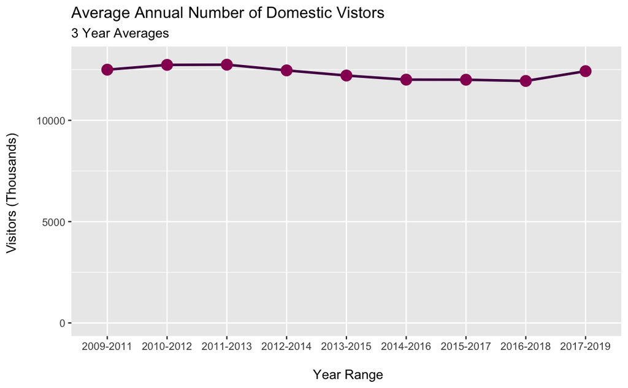

```r
regional_domestic_tourism_all %>%
  ggplot(aes(x = date_code, y = visits)) +
  geom_line(group = 1, size = 1, colour = "#540453") +
  geom_point(colour = "#970061", show.legend = FALSE, size = 4) +
  labs(x = "\n Year Range",
       y = "Visitors (Thousands) \n",
       title = "Average Annual Number of Domestic Vistors",
       subtitle = "3 Year Averages") +
  ylim(0, 13000)
```

### Domestic Tourism / Expenditure

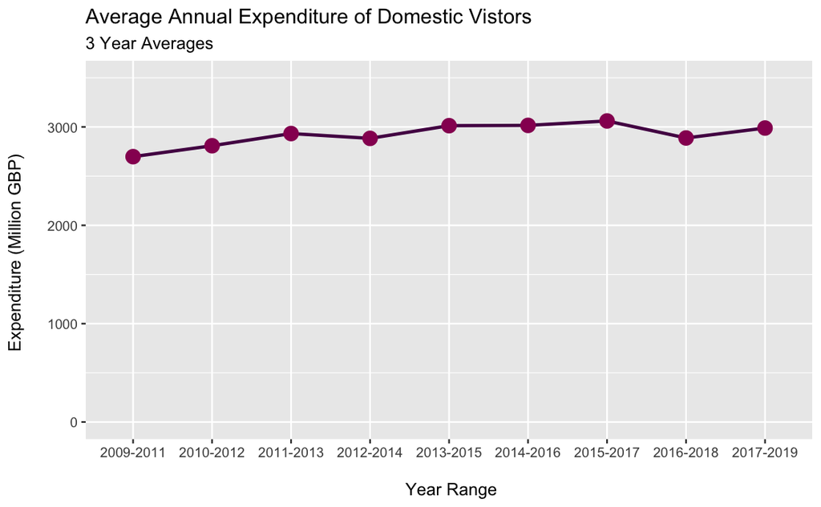

```r
regional_domestic_tourism_all %>%
  ggplot(aes(x = date_code, y = expenditure)) +
  geom_line(group = 1, size = 1, colour = "#540453") +
  geom_point(colour = "#970061", show.legend = FALSE, size = 4) +
  labs(x = "\n Year Range",
       y = "Expenditure (Million GBP) \n",
       title = "Average Annual Expenditure of Domestic Vistors",
       subtitle = "3 Year Averages") +
  ylim(0, 3500)
```

## Domestic Tourism

#### Average Visits By Region

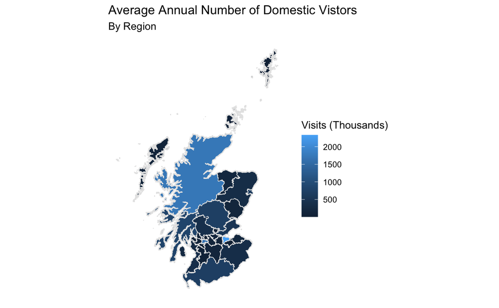

```r
regional_data_joined %>%
  group_by(code) %>%
  summarise(mean_visits = mean(visits)) %>%
  ggplot(aes(fill = mean_visits)) +
  geom_sf(colour = "grey90", size = 0.1) +
  labs(
    x = "Longitude",
    y = "Latitude",
    title = "Average Annual Number of Domestic Vistors",
    subtitle = "By Region",
    fill = "Visits (Thousands)") +
  theme(panel.background = element_rect(fill = "white"),
        axis.text.x = element_blank(),
        axis.text.y = element_blank(),
        axis.ticks = element_blank(),
        rect = element_blank(),
        axis.title.x = element_blank(),
        axis.title.y = element_blank())
```

#### Expenditure by Region

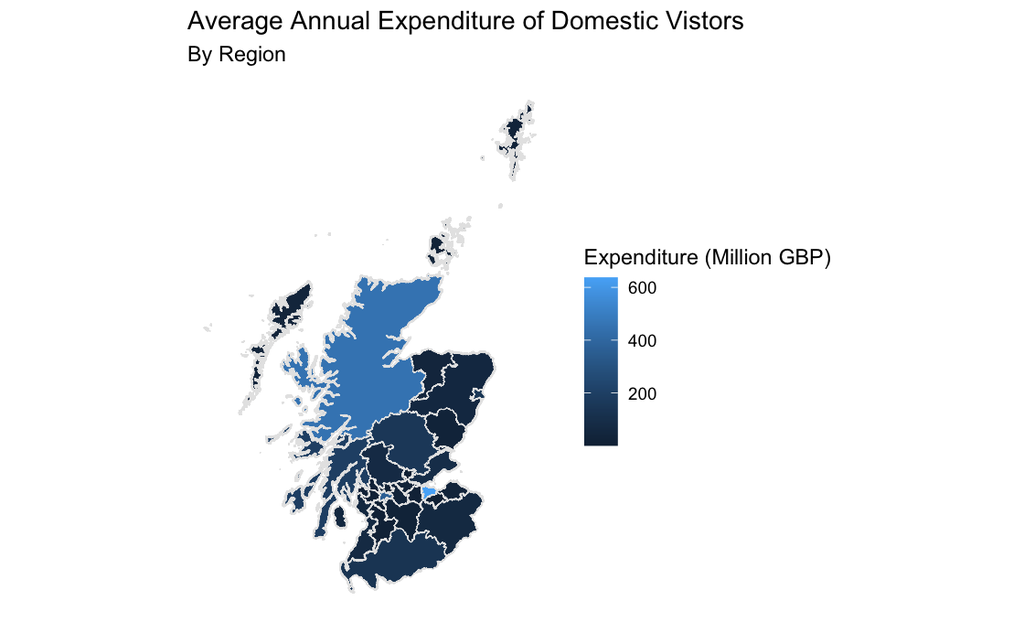

```r
regional_data_joined %>%
  group_by(code) %>%
  summarise(mean_exp = mean(expenditure)) %>%
  ggplot(aes(fill = mean_exp)) +
  geom_sf(colour = "grey90", size = 0.1) +
  labs(
    x = "Longitude",
    y = "Latitude",
    title = "Average Annual Expenditure of Domestic Vistors",
    subtitle = "By Region",
    fill = "Expenditure (Million GBP)") +
    theme(panel.background = element_rect(fill = "white"),
        axis.text.x = element_blank(),
        axis.text.y = element_blank(),
        axis.ticks = element_blank(),
        rect = element_blank(),
        axis.title.x = element_blank(),
        axis.title.y = element_blank())
```

#### Spend Per Visit

##### Mean Spend Per Visit Plot

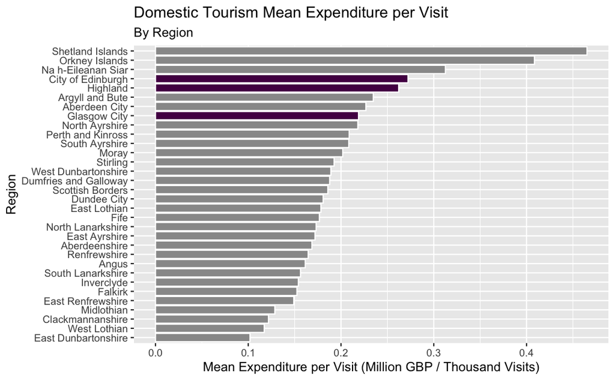

```r
regional_domestic_tourism_individual %>%
  filter(visits != 0,
         expenditure != 0) %>%
  mutate(exp_per_visit = expenditure / visits, rm.na = TRUE) %>%
  group_by(local_authority) %>%
  summarise(mean_exp_per_visit = mean(exp_per_visit)) %>%
  arrange(desc(mean_exp_per_visit)) %>%
  ggplot() +
  geom_col(aes(x = reorder(local_authority, mean_exp_per_visit), y = mean_exp_per_visit,
               fill = local_authority %in% c("City of Edinburgh", "Glasgow City", "Highland")),
           show.legend = FALSE, colour = "white") +
  scale_fill_manual(values = c("FALSE" = "grey60",
                               "TRUE" = "#540453")) +
  coord_flip() +
  labs(
    x = "Region",
    y = "Mean Expenditure per Visit (Million GBP / Thousand Visits)",
    title = "Domestic Tourism Mean Expenditure per Visit",
    subtitle = "By Region")
```

#### Nights Stayed

##### Plot

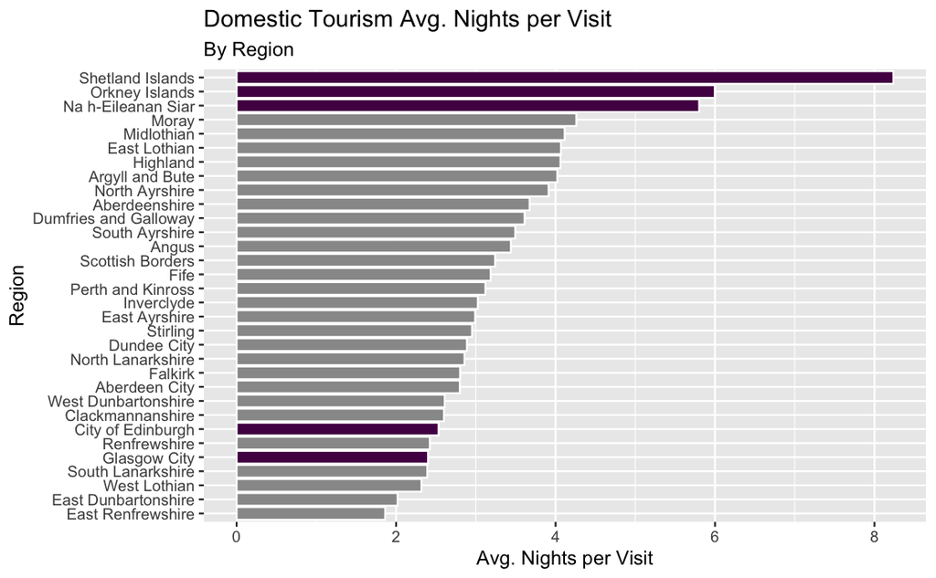

```r
regional_domestic_tourism_individual %>%
  mutate(nights_per_visit = nights / visits) %>%
  group_by(local_authority) %>%
  summarise(mean_nights_per_visit = mean(nights_per_visit, na.rm = TRUE)) %>%
  ggplot() +
  geom_col(aes(x = reorder(local_authority, mean_nights_per_visit), y = mean_nights_per_visit,
               fill = local_authority %in% c("Shetland Islands", "Orkney Islands", "Na h-Eileanan Siar",
                                             "City of Edinburgh", "Glasgow City")),
           show.legend = FALSE, colour = "white") +
  scale_fill_manual(values = c("FALSE" = "grey60",
                               "TRUE" = "#540453")) +
  coord_flip() +
  labs(
    x = "Region",
    y = "Avg. Nights per Visit",
    title = "Domestic Tourism Avg. Nights per Visit",
    subtitle = "By Region")
```

##### Map

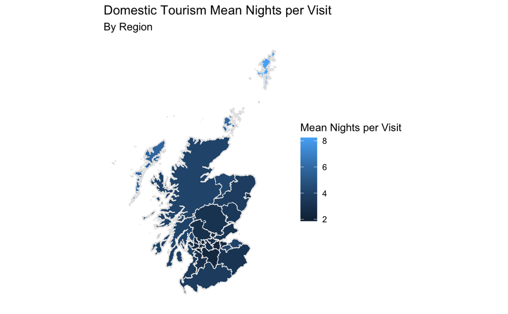

```r
regional_data_joined %>%
  mutate(nights_per_visit = nights / visits) %>%
  group_by(local_authority) %>%
  summarise(mean_nights_per_visit = mean(nights_per_visit, na.rm = TRUE)) %>%
  ggplot(aes(fill = mean_nights_per_visit)) +
  geom_sf(colour = "grey90", size = 0.1) +
  labs(
    x = "Longitude",
    y = "Latitude",
    title = "Domestic Tourism Mean Nights per Visit",
    subtitle = "By Region",
    fill = "Mean Nights per Visit"
  ) +
  theme(panel.background = element_rect(fill = "white"),
        axis.text.x = element_blank(),
        axis.text.y = element_blank(),
        axis.ticks = element_blank(),
        rect = element_blank(),
        axis.title.x = element_blank(),
        axis.title.y = element_blank())
```

```r
NA
```

#### Gross Value Added

```r
tourism_businesses %>%
  filter(local_authority != "Scotland",
         year %in% c(2009, 2010, 2011, 2012, 2013, 2014, 2015, 2016, 2017, 2018, 2019)) %>%
  group_by(local_authority) %>%
  summarise(total_gva = sum(gva)) %>%
  slice_max(total_gva, n = 5)
```

| local_authority | total_gva |
| --- | --- |
| City of Edinburgh | 7129.9 |
| Glasgow City | 4949.3 |
| Aberdeen City | 2673.8 |
| Highland | 2619.7 |
| Fife | 2303.7 |

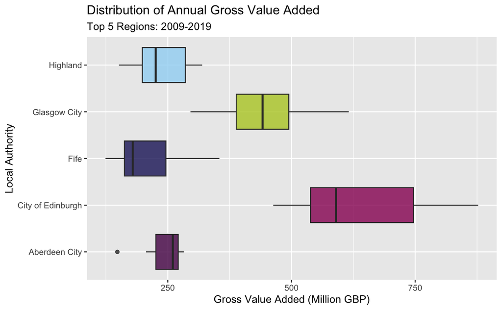

```r
tourism_businesses %>%
  filter(local_authority %in% c("City of Edinburgh", "Glasgow City", "Aberdeen City",
                                "Highland", "Fife"),
         year %in% c(2009, 2010, 2011, 2012, 2013, 2014, 2015, 2016, 2017, 2018, 2019)) %>%
  ggplot() +
  geom_boxplot(aes(x = gva, y = local_authority, fill = local_authority),
               alpha = 0.8,
               show.legend = FALSE) +
  scale_fill_manual(values = c("#540453", "#970061", "#1d1d65", "#b6cb2b", "#9fd6f3")) +
  scale_colour_manual(values = c("#540453", "#970061", "#1d1d65", "#b6cb2b", "#9fd6f3")) +
  labs(
    x = "Gross Value Added (Million GBP)",
    y = "Local Authority",
    title = "Distribution of Annual Gross Value Added",
    subtitle = "Top 5 Regions: 2009-2019"
  )
```

#### Marketing Edinburgh to Domestic Tourists: Mini Case Study

##### Visits by Country of Residence

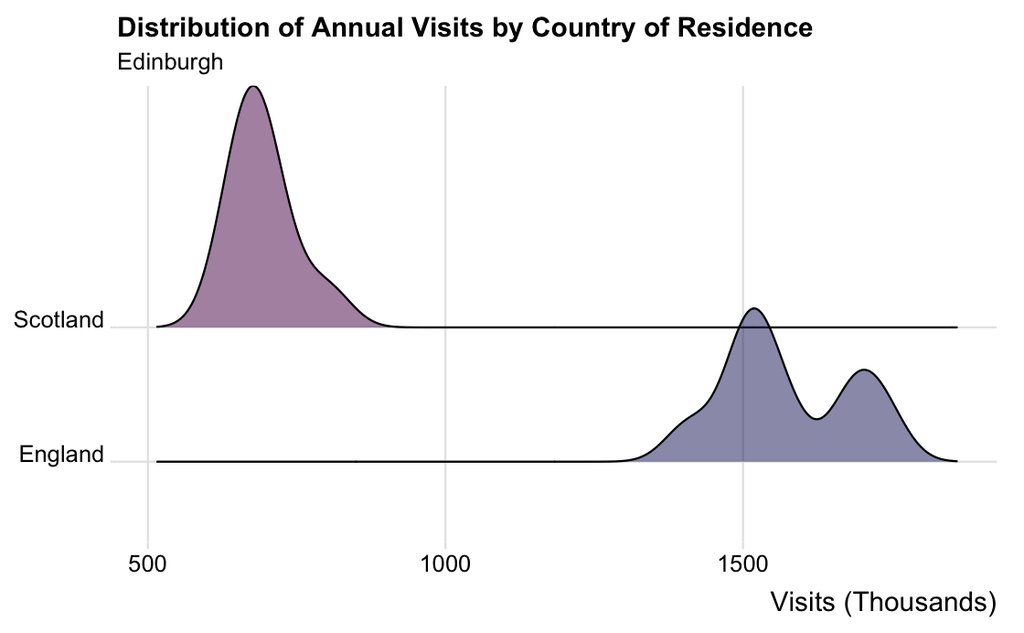

```r
regional_domestic_tourism_non_gb_clean %>%
  filter(local_authority %in% c("City of Edinburgh")) %>%
  ggplot(aes(x = visits, y = region_of_residence, fill = region_of_residence == "Scotland")) +
  geom_density_ridges(show.legend = FALSE, alpha = 0.5) +
  theme_ridges() +
  theme(axis.title.y = element_blank()) +
  scale_fill_manual(values = c("FALSE" = "#1d1d65",
                               "TRUE" = "#540453")) +
  labs(
    title = "Distribution of Annual Visits by Country of Residence",
    subtitle = "Edinburgh",
    x = "Visits (Thousands)")
```

##### Spend Per Visit by Country of Residence

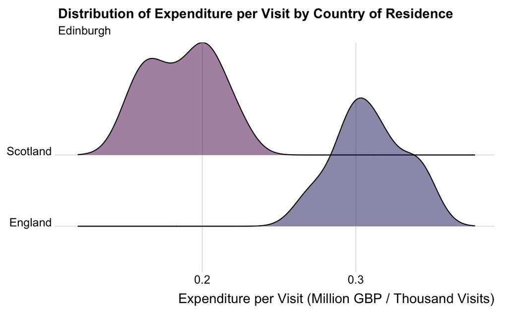

```r
regional_domestic_tourism_non_gb_clean %>%
  filter(local_authority %in% c("City of Edinburgh")) %>%
  mutate(exp_per_visit = expenditure / visits) %>%
  ggplot(aes(x = exp_per_visit, y = region_of_residence, fill = region_of_residence == "Scotland")) +
  geom_density_ridges(show.legend = FALSE, alpha = 0.5) +
  theme_ridges() +
  theme(axis.title.y = element_blank()) +
  scale_fill_manual(values = c("FALSE" = "#1d1d65",
                               "TRUE" = "#540453")) +
  labs(
    title = "Distribution of Expenditure per Visit by Country of Residence",
    subtitle = "Edinburgh",
    x = "Expenditure per Visit (Million GBP / Thousand Visits)")
```

##### Nights by Country of Residence

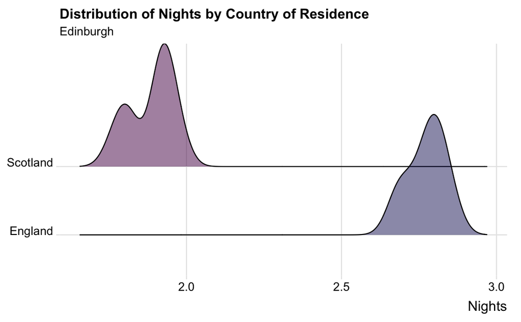

```r
regional_domestic_tourism_non_gb_clean %>%
  filter(local_authority %in% c("City of Edinburgh")) %>%
  mutate(nights_per_visit = nights / visits) %>%
  ggplot(aes(x = nights_per_visit, y = region_of_residence, fill = region_of_residence == "Scotland")) +
  geom_density_ridges(show.legend = FALSE, alpha = 0.5) +
  theme_ridges() +
  theme(axis.title.y = element_blank()) +
  scale_fill_manual(values = c("FALSE" = "#1d1d65",
                               "TRUE" = "#540453")) +
  labs(
    title = "Distribution of Nights by Country of Residence",
    subtitle = "Edinburgh",
    x = "Nights")
```

##### Linear Model: Predict Spend by Visits & Nights?

```r
regional_domestic_tourism_non_gb_clean %>%
  filter(local_authority == "City of Edinburgh",
         region_of_residence == "England") %>%
  summarise(cor(expenditure, visits))
```

| cor(expenditure, visits) |
| --- |
| 0.9863089 |

```r
regional_domestic_tourism_non_gb_clean %>%
  filter(local_authority == "City of Edinburgh",
         region_of_residence == "England") %>%
  summarise(cor(expenditure, nights))
```

| cor(expenditure, nights) |
| --- |
| 0.9726249 |

```r
edinburgh_england <- regional_domestic_tourism_non_gb_clean %>%
  filter(local_authority == "City of Edinburgh",
         region_of_residence == "England")
```

```r
model_edinburgh <- lm(formula = expenditure ~ visits, data = edinburgh_england)
summary(model_edinburgh)
```

```
Call:
lm(formula = expenditure ~ visits, data = edinburgh_england)

Residuals:
    Min      1Q  Median      3Q     Max
-24.193  -4.918   4.838   6.423  14.165

Coefficients:
              Estimate Std. Error t value Pr(>|t|)
(Intercept) -493.61749   62.18315  -7.938 9.58e-05 ***
visits         0.62423    0.03945  15.824 9.76e-07 ***
---
Signif. codes:  0 ‘***’ 0.001 ‘**’ 0.01 ‘*’ 0.05 ‘.’ 0.1 ‘ ’ 1

Residual standard error: 12.34 on 7 degrees of freedom
Multiple R-squared:  0.9728,    Adjusted R-squared:  0.9689
F-statistic: 250.4 on 1 and 7 DF,  p-value: 9.756e-07
```

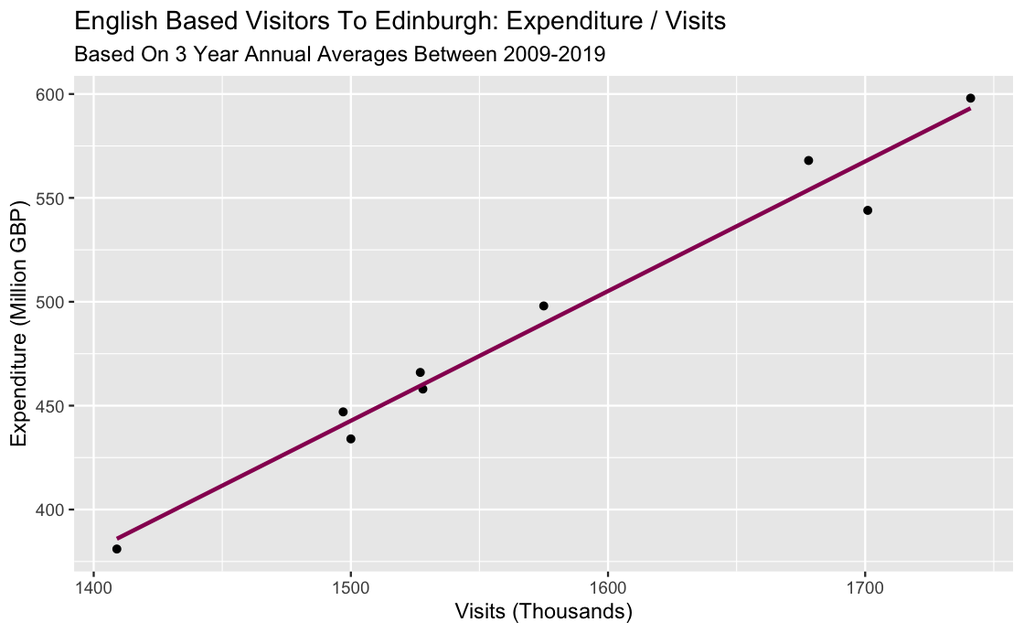

```r
edinburgh_england %>%
  add_predictions(model_edinburgh) %>%
  add_residuals(model_edinburgh) %>%
  ggplot(aes(x = visits, y = expenditure)) +
  geom_point() +
  geom_line(aes(y = pred), col = "#970061", size = 1) +
  labs(
    x = "Visits (Thousands)",
    y = "Expenditure (Million GBP)",
    title = "English Based Visitors To Edinburgh: Expenditure / Visits",
    subtitle = "Based On 3 Year Annual Averages Between 2009-2019")
```

Model: spend ~ visits

Interpretation: ~97% of the variation in expenditure can be explained by the number of visits.

Question: The largest increase in visitor numbers is from 2009-2011 Avg. to 2010-2012 Avg. ~6%. If this percentage increase in visits was replicated in based on the most recent set of figures resulting in ~1803 (Thousand) visitors - what would the model predict for expenditure?

Answer: If visits were increased as above, the model would predict expenditure of ~632 Million GBP (Low Estimate ~620, High Estimate ~644)

As calculated below.

Step 1. outcome = b0 + b1 * 1st Predictor

Step 2. expenditure = b0(intercept) + b1(coefficient) * 1st Predictor

Step 3. expenditure = b0(intercept) + b1(coefficient) * `visits`

Step 4. expenditure = -493.61749 + 0.62423 * `1803`

Step 5. expenditure = ~632 (Low Estimate ~620, High Estimate ~644)

```r
632 + c(-12.34, 12.34)
```

```
[1] 619.66 644.34
```

## International Tourism

### Annual Average Stats

#### Mean

```r
international_visits %>%
  filter(year %in% c(2009, 2010, 2011, 2012, 2013, 2014, 2015, 2016, 2017, 2018, 2019)) %>%
  group_by(year) %>%
  summarise(sum_annual_visits = sum(visits),
            sum_annual_spend = sum(spend)) %>%
  summarise(mean_annual_visits = mean(sum_annual_visits),
            mean_annual_spend = mean(sum_annual_spend))
```

| mean_annual_visits | mean_annual_spend |
| --- | --- |
| 2795.579 | 1843.101 |

### Visitors by Country of Residence

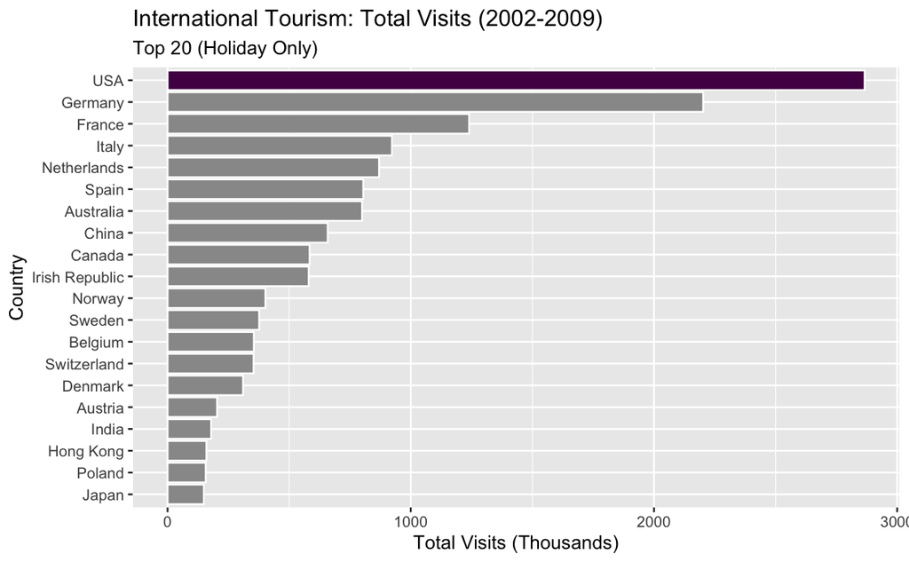

```r
international_visits %>%
  select(-c(quarter, age, sample)) %>%
  filter(year %in% c(2009, 2010, 2011, 2012, 2013, 2014, 2015, 2016, 2017, 2018, 2019),
         purpose == "Holiday") %>%
  group_by(country) %>%
  summarise(total_visits = sum(visits)) %>%
  slice_max(total_visits, n = 20) %>%
  ggplot(aes(x = reorder(country, total_visits), y = total_visits)) +
  geom_col(aes(x = reorder(country, total_visits), y = total_visits,
               fill = country %in% c("USA")),
           show.legend = FALSE, colour = "white") +
  scale_fill_manual(values = c("FALSE" = "grey60",
                               "TRUE" = "#540453")) +
  coord_flip() +
  labs(
    x = "Country",
    y = "Total Visits (Thousands)",
    title = "International Tourism: Total Visits (2002-2009)",
    subtitle = "Top 20 (Holiday Only)")
```

### Spend by Country of Residence

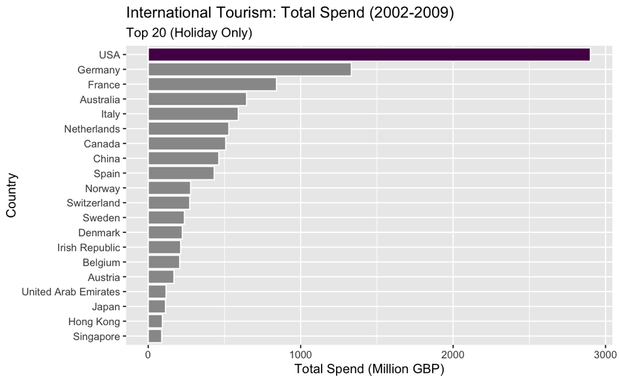

```r
international_visits %>%
  select(-c(quarter, age, sample)) %>%
  filter(year %in% c(2009, 2010, 2011, 2012, 2013, 2014, 2015, 2016, 2017, 2018, 2019),
         purpose == "Holiday") %>%
  group_by(country) %>%
  summarise(total_spend = sum(spend)) %>%
  slice_max(total_spend, n = 20) %>%
  ggplot() +
  geom_col(aes(x = reorder(country, total_spend), y = total_spend,
               fill = country %in% c("USA")),
           show.legend = FALSE, colour = "white") +
  scale_fill_manual(values = c("FALSE" = "grey60",
                               "TRUE" = "#540453")) +
  coord_flip() +
  labs(
    x = "Country",
    y = "Total Spend (Million GBP)",
    title = "International Tourism: Total Spend (2002-2009)",
    subtitle = "Top 20 (Holiday Only)")
```

### Spend per Visit by Country of Residence

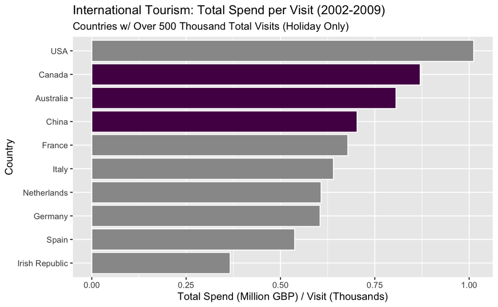

```r
international_visits %>%
  select(-c(quarter, age, sample)) %>%
  filter(year %in% c(2009, 2010, 2011, 2012, 2013, 2014, 2015, 2016, 2017, 2018, 2019),
         purpose == "Holiday") %>%
  group_by(country) %>%
  summarise(total_spend = sum(spend),
            total_visits = sum(visits),
            spend_per_visit = total_spend / total_visits) %>%
  filter(total_visits > 500) %>%
  ggplot() +
  geom_col(aes(x = reorder(country, spend_per_visit), y = spend_per_visit,
               fill = country %in% c("Australia", "China", "Canada")),
           show.legend = FALSE, colour = "white") +
  scale_fill_manual(values = c("FALSE" = "grey60",
                               "TRUE" = "#540453")) +
  coord_flip() +
  labs(
    x = "Country",
    y = "Total Spend (Million GBP) / Visit (Thousands)",
    title = "International Tourism: Total Spend per Visit (2002-2009)",
    subtitle = "Countries w/ Over 500 Thousand Total Visits (Holiday Only)")
```

### Group of High Value Countries

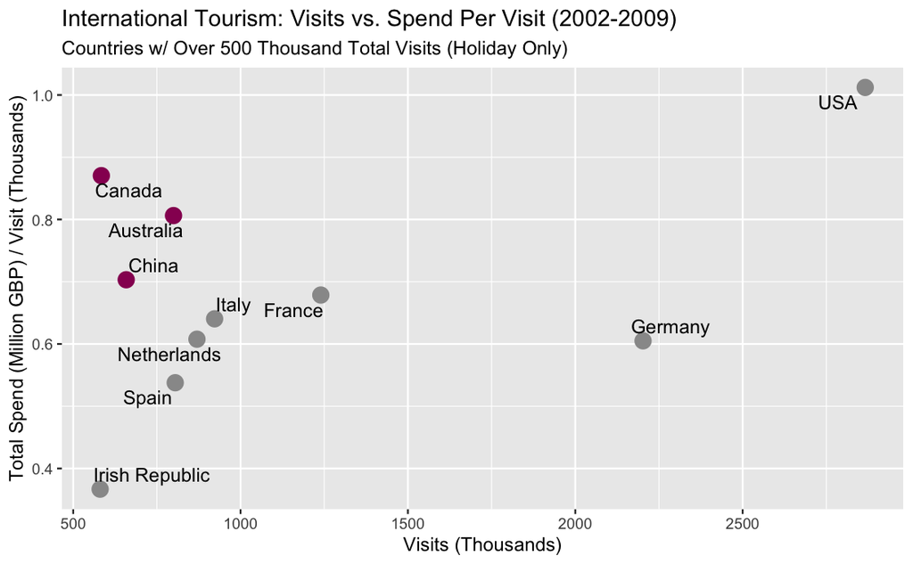

```r
international_visits %>%
  select(-c(quarter, age, sample)) %>%
  filter(year %in% c(2009, 2010, 2011, 2012, 2013, 2014, 2015, 2016, 2017, 2018, 2019),
         purpose == "Holiday") %>%
  group_by(country) %>%
  summarise(total_spend = sum(spend),
            total_visits = sum(visits),
            spend_per_visit = total_spend / total_visits) %>%
  filter(total_visits > 500) %>%
  ggplot(aes(x = total_visits, y = spend_per_visit)) +
  geom_point(aes(colour = country %in% c("Australia", "China", "Canada")),
             show.legend = FALSE,
             size = 4) +
  scale_colour_manual(values = c("FALSE" = "grey60",
                                 "TRUE" = "#970061")) +
  ggrepel::geom_text_repel(aes(x = total_visits, y = spend_per_visit, label = country)) +
  labs(
    x = "Visits (Thousands)",
    y = "Total Spend (Million GBP) / Visit (Thousands)",
    title = "International Tourism: Visits vs. Spend Per Visit (2002-2009)",
    subtitle = "Countries w/ Over 500 Thousand Total Visits (Holiday Only)")
```

### By Region Visited

“Information at the regional level is often based on very small sample sizes”  
“The International Passenger Survey is a national survey, and is not designed to be statistically robust at the regional level.”

### By Season

```r
international_visits %>%
  filter(country == "Canada",
         purpose == "Holiday") %>%
  mutate(exp_per_visit = spend / visits,
         spring_summer = if_else(quarter %in% c("Quarter 2", "Quarter 3"), "Yes", "No")) %>%  group_by(spring_summer) %>%
  summarise(mean_visits = mean(visits),
            mean_exp = mean(spend),
            mean_exp_per_visit = mean(exp_per_visit))
```

| spring_summer | mean_visits | mean_exp | mean_exp_per_visit |
| --- | --- | --- | --- |
| No | 0.8639457 | 0.5415866 | 0.5991019 |
| Yes | 1.3187552 | 1.0793552 | 0.7121640 |

```r
canada_sample <- international_visits %>%
  filter(country == "Canada",
         purpose == "Holiday") %>%
  mutate(exp_per_visit = spend / visits,
         spring_summer = if_else(quarter %in% c("Quarter 2", "Quarter 3"), "Yes", "No"))
```

```r
observed_stat <- canada_sample %>%
  specify(exp_per_visit ~ spring_summer) %>%
  calculate(stat = "diff in means", order = c("Yes", "No"))

observed_stat
```

```
Response: exp_per_visit (numeric)
Explanatory: spring_summer (factor)
```

| stat |
| --- |
| 0.1130621 |

```r
null_distribution <- canada_sample %>%
  specify(response = exp_per_visit, explanatory = spring_summer) %>%
  hypothesize(null = "independence") %>%
  generate(reps = 1000, type = "permute") %>%
  calculate(stat = "diff in means", order = c("Yes", "No"))
```

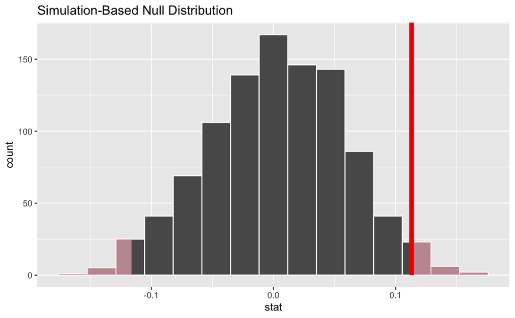

```r
null_distribution %>%
  visualise() +
  shade_p_value(obs_stat = observed_stat, direction = "both")
```

```r
null_distribution %>%
  get_p_value(obs_stat = observed_stat, direction = "both")
```

| p_value |
| --- |
| 0.04 |